# periodic_alpha_filtration

## 周期アルファフィルタレーション

対象となるデータは`periodic_pointcloud.txt`というファイルです。 これは3次元一様分布に従うランダムな点(各座標0~1)を5000個撒き散らしたものです。これを解析してみましょう。

まずこれを表示します。最初の10行を見てみましょう。

```bash
head periodic_pointcloud.txt
```

```
2.354726207228192703e-01 4.529910793960023607e-02 2.368249750095773321e-01
9.602122576630891526e-01 9.549736053842968753e-01 7.440951163360988163e-01
3.326382548503425962e-02 5.846466783398807099e-02 2.105108052278514830e-02
4.121921464235077659e-01 7.270236021041442953e-01 4.006982391578239877e-02
2.069817779959027826e-01 8.740064587207674318e-01 8.198285009137098456e-01
7.418221346418505391e-01 5.288209872904583442e-01 2.310887547603618364e-01
9.184535192147282867e-01 8.341002991696571112e-01 6.318195415206102616e-01
2.167305938406398624e-01 4.159730130874439435e-01 5.301015382837006573e-01
3.911052626903448459e-01 3.434388206595408999e-01 6.978735068635681937e-01
1.678321854736883889e-01 4.705032724726665450e-04 7.328227907686728493e-01
```

このようにデータが3列で並んでいます。 データから周期的パーシステント図を計算します。 --periodicというオプションを使用します。

```bash
python3 -m homcloud.pc_alpha -d 3 --periodic 0 1 0 1 0 1 periodic_pointcloud.txt periodic_pointcloud.pdgm
```

0 1 0 1 0 1はそれぞれデータのx座標の最小値、最大値、y座標の最小値、最大値、z座標の最小値、最大値を表しています。 一様分布のデータを使用する理由は、周期境界条件を付けるわけなので境界の端の方にもそれなりに点が詰まっていないと上手く動作しないからです。 0 1 0 1 0 1にした場合、{0,1}x{0,1}x{0,1}を一単位の周期ボックスとしてそれをプログラム側が並べて計算します。周期的なドロネー三角形分割を作るのですが周期ボックスの端っこの方でそれを張り合わせて周期的な三角形分割を作るようになっています。なので周期ボックスの端っこの方にそれなりに点が詰まっていないと、同じ始点と終点を共有する辺が出来たり、ループ辺ができたりするので、数学理論とプログラムの実装の両方の問題で都合が悪いです。

### パーシステント図の可視化

次にここからパーシステント図をプロットしてみましょう。

```bash
python3 -m homcloud.plot_PD -d 1 periodic_pointcloud.pdgm -o periodic_pointcloud-pd1.png
```

すると以下のような画像が出力されます。

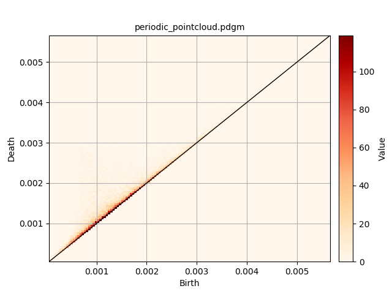

```bash
display < periodic_pointcloud-pd1.png
```

スケールをログスケールに直します。

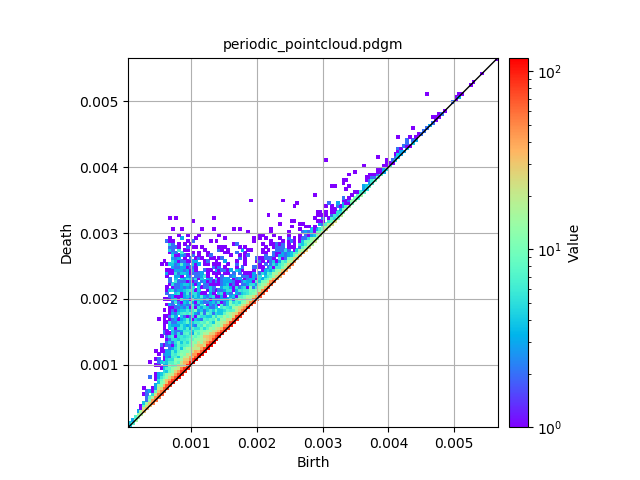

```bash
python3 -m homcloud.plot_PD -d 1 -l --aspect equal periodic_pointcloud.pdgm -o periodic_pointcloud-pd1-log.png
display < periodic_pointcloud-pd1-log.png
```

さて、次にbirth-death pairが集中している 左下の 0.000〜0.003 のあたりを拡大して調べてみましょう。

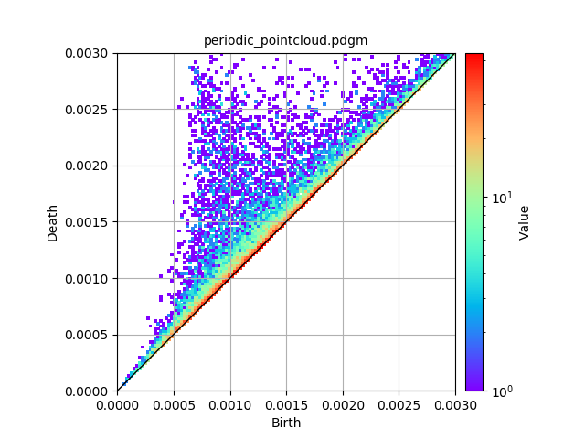

```bash
python3 -m homcloud.plot_PD -d 1 -l -x "[0:0.003]" --aspect equal periodic_pointcloud.pdgm -o periodic_pointcloud-pd1-zoomup.png
display < periodic_pointcloud-pd1-zoomup.png
```

解像度を上げます。

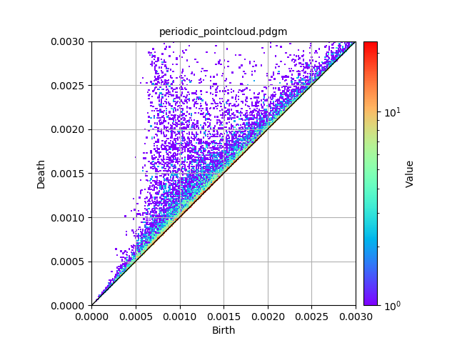

```bash
python3 -m homcloud.plot_PD -d 1 -l -x "[0:0.003]" -X 256 --aspect equal periodic_pointcloud.pdgm -o periodic_pointcloud-pd1-zoomup.png
display < periodic_pointcloud-pd1-zoomup.png
```

`plot_PD_gui`を使用して見ます。

```bash
python3 -m homcloud.plot_PD_gui -d 1 periodic_pointcloud.pdgm
```

```
Attribute Qt::AA_EnableHighDpiScaling must be set before QCoreApplication is created.
```

### テキストデータでの解析

次にパーシステント図をテキストデータとして出力してみましょう。

```bash
# データの行数が多いので最後の10行だけを tail で表示する
python3 -m homcloud.dump_diagram -S no -d 1 periodic_pointcloud.pdgm | tail
```

```
0.005049083164886557 0.005056192275892211
0.005061499978982112 0.005062705067590233
0.005064156668483196 0.005084749642542166
0.005101004608537771 0.005108227630965493
0.00458623119256343 0.005116308540594936
0.005089249122723015 0.005127950601040435
0.005261736305515731 0.005261755286710288
0.005307973670775357 0.005311186917878161
0.005413847962230849 0.005417057287224216
0.005661916701954425 0.005662938821148851
```

すると2列の数値データが出力されます。これは1次のbirth-death pairすべてを列挙していて、左側の数値がbirth time、右側の数値がdeath timeです。

`-o`オプションを使って以下のように1次のbirth-death pairの情報をテキストで保存します。

```bash
python3 -m homcloud.dump_diagram -S no -d 1 periodic_pointcloud.pdgm -o periodic_pointcloud-pd1.txt
```

### 簡単な逆解析

パーシステント図の個々の点は何らかの意味で元のポイントクラウドのリング構造、空隙構造と対応しているはずです。HomCloudの基本的な逆解析のツールであるbirth simplex、death simplexというものを使ってみましょう。これには`-S`オプションに`yes`を渡すと表示されます。

```bash
python3 -m homcloud.dump_diagram -S yes -d 1 periodic_pointcloud.pdgm -o periodic_pointcloud-pd1.txt
# head で最初の3行だけ表示している
head -n 3 periodic_pointcloud-pd1.txt
```

[output not shown]

[output not shown]

の2つの点を結んだ辺が「現れた」タイミングで生じ、

[output not shown]

の3つの点を頂点とする3角形が「現れた」タイミングで消えたことを意味します。 。この出力結果はファイル`periodic_pointcloud-pd1.txt`に保存されていますので、それをさらに解析することでリングの空間分布を調べるようなこともできます。

### 高度な逆解析機能(Optimal Volume)

次は HomCloud の強力な逆解析ツールである、optimal volumeを使いましょう。 とりあえずさきほど表示したパーシステント図をもう一度見てみましょう。

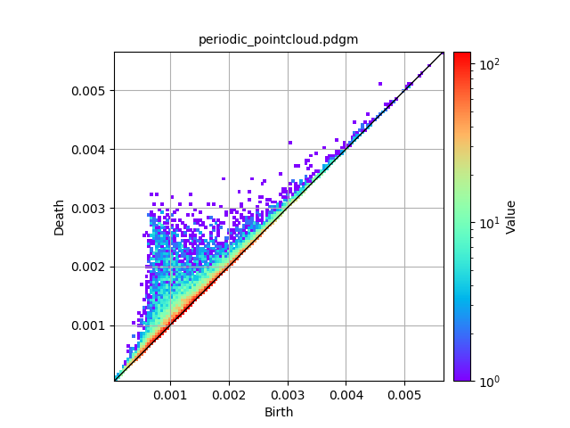

```bash
display < periodic_pointcloud-pd1-log.png
```

```bash
python3 -m homcloud.optvol -d 1 -x 0.0008 -y 0.0032 -P periodic_pointcloud.pdgm
```

するとparaviewのウィンウドウが表示されたはずです。周期境界条件の計算は結構高コストです． 左側のパネルの「Apply」ボタンを押すと表示がされます。

[figure not shown]

表示は周期境界条件を考慮しないので可視化はけっこうぐちゃぐちゃになります．これは今後改善する予定です．

この情報は ファイルに保存することもできます。以下のようにします。

```bash
python3 -m homcloud.optvol -d 1 -x 0.0008 -y 0.0032 -j periodic_optimal_volume.json periodic_pointcloud.pdgm
```

`periodic_optimal_volume.json`にoptimal volumeの情報が保存されています。

以上でこのチュートリアルは終わりです。お疲れさまでした。